# Redes

Author

Mateo Vega

## Qué son datos de redes

Las redes son datos que consisten de entidades (**ndoos o vertices**) y sus relaciones (**edges o links**). Estos datos no son representables en un sólo data frame, sin embargo se puede codificar como dos data frames, uno codificando los nodos y uno codificando los edges.

### Una API tidy de manipulación de redes

`tidygraph` se puede considerar una API para datos de redes, por ejemplo se crea una red aleatoria usando el método **Erdos-Renyi** de muestreo

```r
library(tidygraph)
library(ggplot2)

graph <- play_erdos_renyi(n = 10, p = 0.2) |>
  activate(nodes) |>
  mutate(class = sample(letters[1:4], n(), replace = TRUE)) |>
  activate(edges) |>
  arrange(.N()$class[from])

graph
```

```
# A tbl_graph: 10 nodes and 21 edges
#
# A directed simple graph with 1 component
#
# A tibble: 21 × 2
   from    to
  <int> <int>
1     6     1
2     9     1
3     6     2
4     9     5
5     6    10
6     9     7
# ℹ 15 more rows
#
# A tibble: 10 × 1
  class
  <chr>
1 a
2 c
3 b
# ℹ 7 more rows
```

`activate()` le informa a tidygraph qué parte de la red se está trabajando, `.N()` da acceso a los datos del nodo del grafo así se esté trabajando en los bordes (también existe `.E()` para acceder a los bordes y `.G()` para acceder al grafo.)

### Conversión

Los datos de resdes pueden ser presentados en diferentes formatos dependiendo de donde se obtengan. Se puede usar `as_tbl_graph()` para convertirlos. Un ejemplo de convertir un dataframe codificado como **edgelist** y convertir el resultado de `hclust()`

```r
data(highschool, package = "ggraph")
head(highschool)
```

```
  from to year
1    1 14 1957
2    1 15 1957
3    1 21 1957
4    1 54 1957
5    1 55 1957
6    2 21 1957
```

```r
hs_graph <- as_tbl_graph(highschool, directed = FALSE)
hs_graph
```

```
# A tbl_graph: 70 nodes and 506 edges
#
# An undirected multigraph with 1 component
#
# A tibble: 70 × 1
  name
  <chr>
1 1
2 2
3 3
4 4
5 5
6 6
# ℹ 64 more rows
#
# A tibble: 506 × 3
   from    to  year
  <int> <int> <dbl>
1     1    13  1957
2     1    14  1957
3     1    20  1957
# ℹ 503 more rows
```

```r
luv_clust <- hclust(dist(luv_colours[, 1:3]))
luv_graph <- as_tbl_graph(luv_clust)
luv_graph
```

```
# A tbl_graph: 1313 nodes and 1312 edges
#
# A rooted tree
#
# A tibble: 1,313 × 4
  height leaf  label members
   <dbl> <lgl> <chr>   <int>
1     0  TRUE  "101"       1
2     0  TRUE  "427"       1
3   778. FALSE ""          2
4     0  TRUE  "571"       1
5     0  TRUE  "426"       1
6     0  TRUE  "424"       1
# ℹ 1,307 more rows
#
# A tibble: 1,312 × 2
   from    to
  <int> <int>
1     3     1
2     3     2
3     8     6
# ℹ 1,309 more rows
```

tidygraph agrega la información automáticamente cuando convierte, por ejemplo el año.

### Algorítmos

tidygraph tiene soporte para muchos algoritmos como por ejemplo calculos de centralidad, ranking, agrupamiento. El API del algoritmo está diseñado para ser usado dentro de `mutate()` y siempre devuelve un vector.

```r
graph |>
  activate(nodes) |>
  mutate(centrality = centrality_pagerank()) |>
  arrange(desc(centrality))
```

```
# A tbl_graph: 10 nodes and 21 edges
#
# A directed simple graph with 1 component
#
# A tibble: 10 × 2
  class centrality
  <chr>      <dbl>
1 b         0.197
2 c         0.143
3 c         0.125
4 a         0.117
5 a         0.112
6 c         0.0913
# ℹ 4 more rows
#
# A tibble: 21 × 2
   from    to
  <int> <int>
1    10     5
2     4     5
3    10     7
# ℹ 18 more rows
```

## Visualizar redes

Para mostrar la topología se emplean **layouts**. Estos son algorítmos que usan la estructura de redes para calcular (a veces arbitrariamente) valores de `x` y `y` para cada nodo para que se puedan visualizar.

### Configurando la visualización

ggraph inicia con `ggraph()`, el primer argumento son los datos, puede ser un **tbl_graph** o un objeto que se pueda convertir en uno. El segundo argumento es la función **layout** y los argumentos pasados a la función. Por defecto la **layout** escogida se escogerá una apropiada para el tipo de grafo. [Guia para layouts](https://ggraph.data-imaginist.com/articles/Layouts.html).

### Especificar un **layout**

Este argumento puede tener una cadena o una función que coincida con alguno de los **layouts** incluidos.

```
Using "stress" as default layout
```

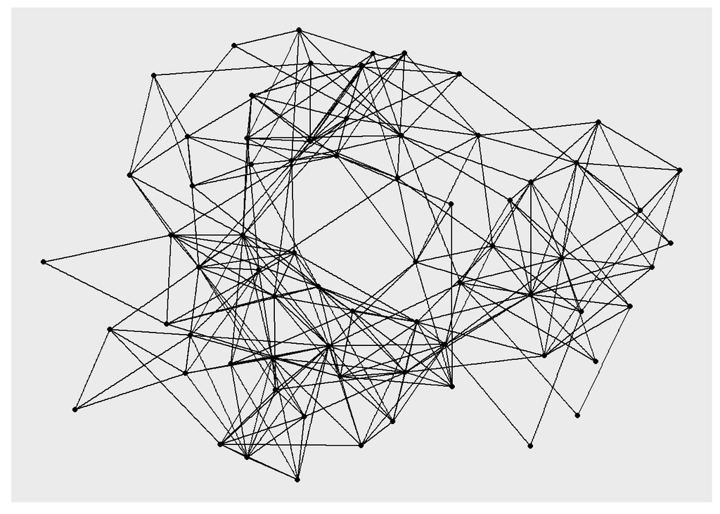

```r
library(ggraph)
ggraph(hs_graph) + # por defecto
  geom_edge_link() +
  geom_node_point()
```

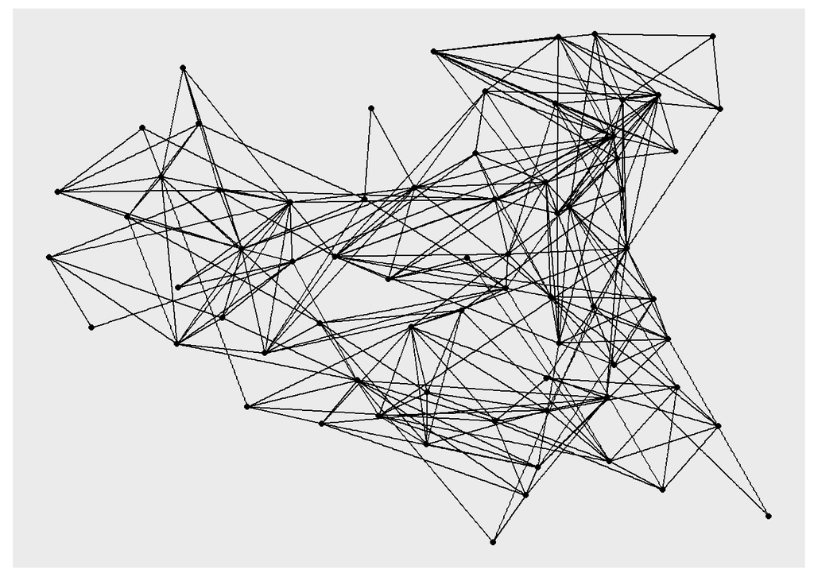

```r
ggraph(hs_graph, layout = "drl") +
  geom_edge_link() +
  geom_node_point()
```

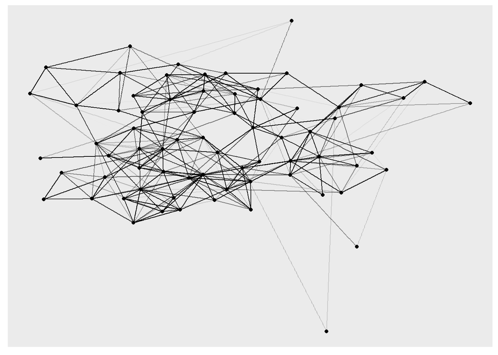

```r
hs_graph <- hs_graph |>
  activate(edges) |>
  mutate(edge_weights = runif(n()))
ggraph(hs_graph, layout = "stress", weights = edge_weights) +
  geom_edge_link(aes(alpha = edge_weights)) +
  geom_node_point() +
  scale_edge_alpha_identity()
```

### Circularidad

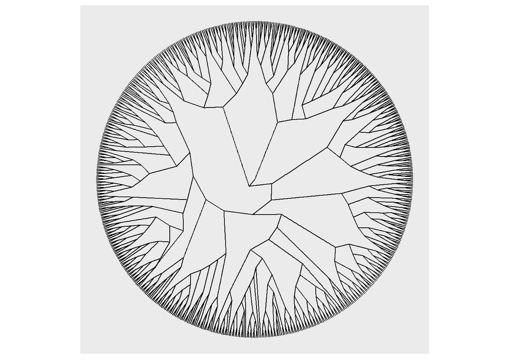

```r
ggraph(luv_graph, layout = "dendrogram", circular = TRUE) +
  geom_edge_link() +
  coord_fixed()
```

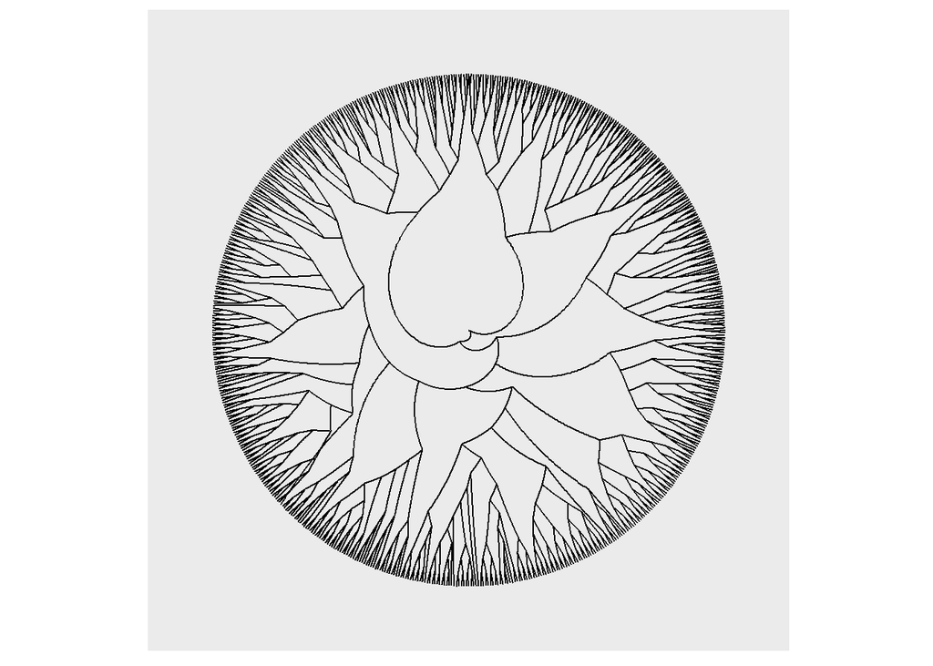

```r
ggraph(luv_graph, layout = "dendrogram") +
  geom_edge_link() +
  coord_polar() +
  scale_y_reverse()
```

`coord_polar()` dobla nuestros bordes, lo cual no queremos.

### Dibujando nodos

Estos son dibujados como puntos de la misma forma que los puntos en un gráfico de dispersión [Guia nodos](https://ggraph.data-imaginist.com/articles/Nodes.html). Todos las geometrías está en `geom_node_` y la más usada es `geom_node_point()`. No se necesita especificar el `x` y `y`, el mapeado es implícito. Tenemos acceso a `filter()` que permite no dibujar nodos en especifico. También se pueden usar algorítmos dentro de `aes()` y se evalúan en el grafo visualizado.

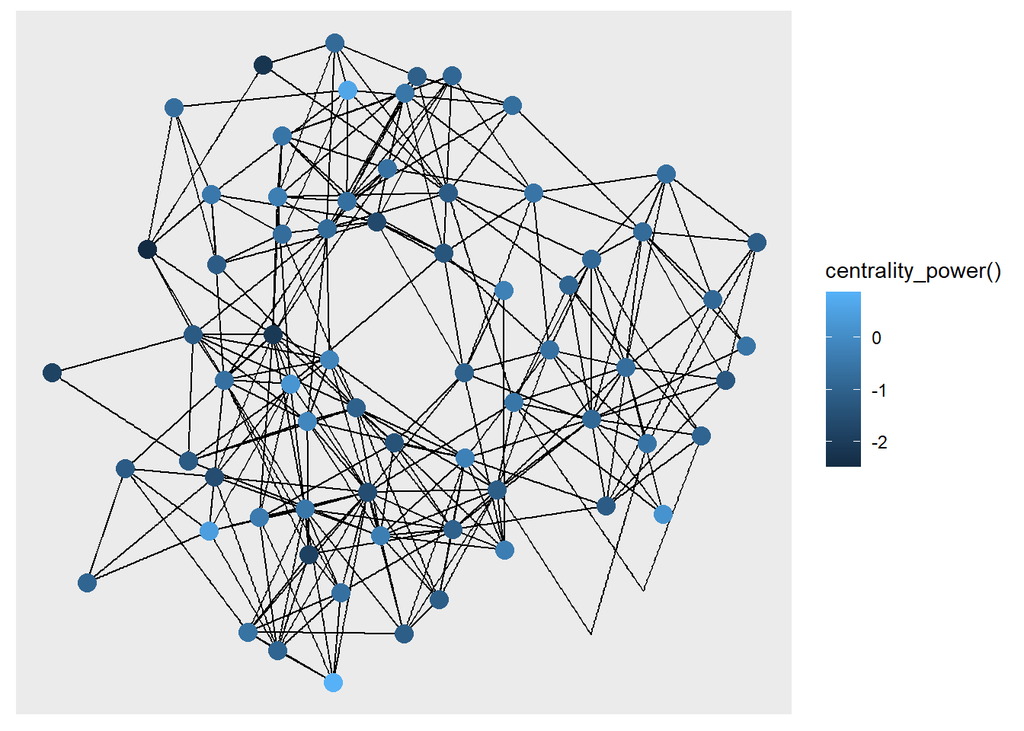

```r
ggraph(hs_graph, layout = "stress") +
  geom_edge_link() +
  geom_node_point(
    aes(filter = centrality_degree() > 2,
        colour = centrality_power()),
    size = 4
  )
```

Hay geometrías mas especializadas, muchas atadas a un tipo especifico de **layout**

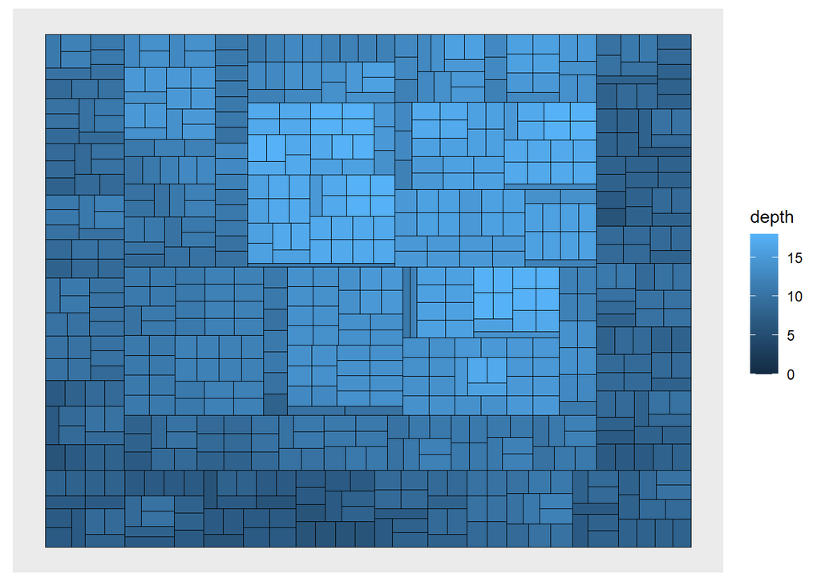

```r
ggraph(luv_graph, layout = "treemap") +
  geom_node_tile(aes(fill = depth))
```

### Dibujando bordes

Estos son más complicados que los nodos, debido a que hay muchas formas de conectar dos cosas. [Guia bordes](https://ggraph.data-imaginist.com/articles/Edges.html). `geom_edge_link()` dibuja una linea recta entre nodos, por dentro divide la linea en muchos fragmentos pequeños y es posible dibujar un gradiente con el borde para mostrar dirección’

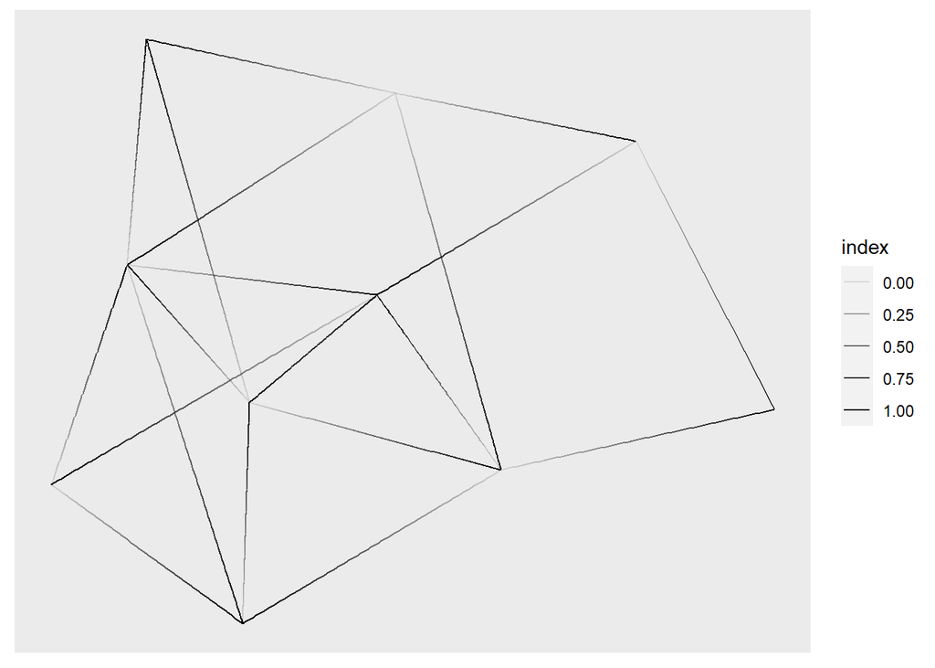

```r
ggraph(graph, layout = "stress") +
  geom_edge_link(aes(alpha = after_stat(index)))
```

Esta expansión se vuelve problemática si se dibujan muchos bordes, ggraph la dibj=uja como una geometría simple que no permite gradiente. Ahora, si se quiere interpolar entre dos valores en los puntos finales

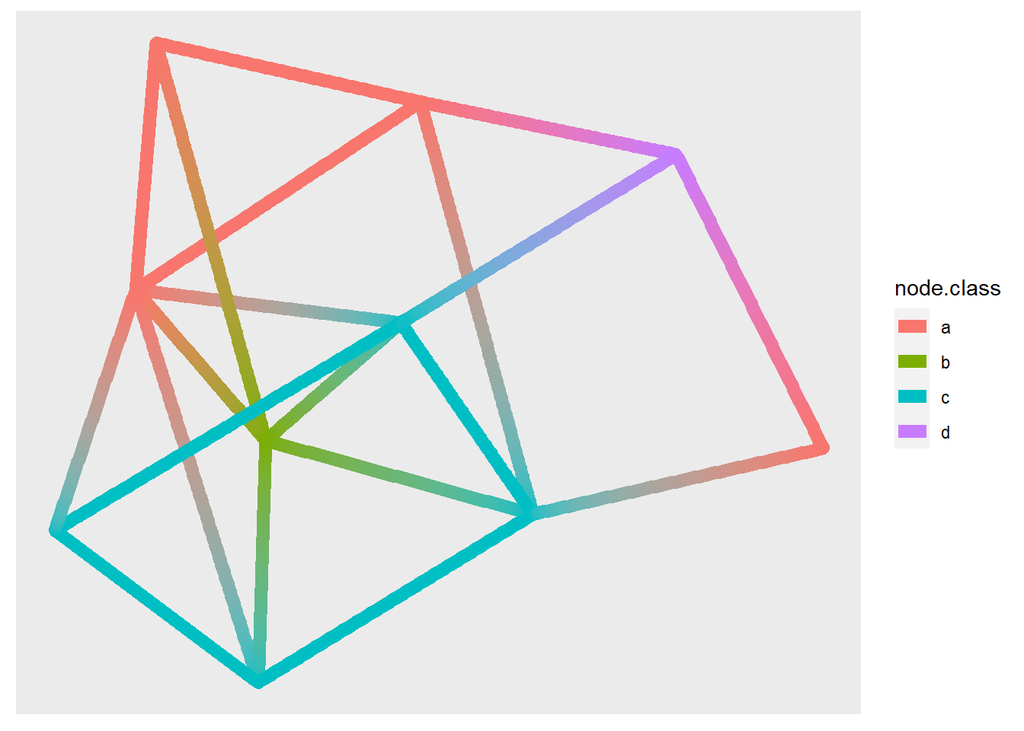

```r
ggraph(graph, layout = "stress") +
  geom_edge_link2(
    aes(colour = node.class),
    width = 3,
    lineend = "round"
  )
```

Cuando se tienen varios multiples bordes entre nlos mismos nodos, usar una linea recta haría que desaparecieran algunas conexiones, se puede usar `geom_edge_fan()` o `geom_edge_parallel()`

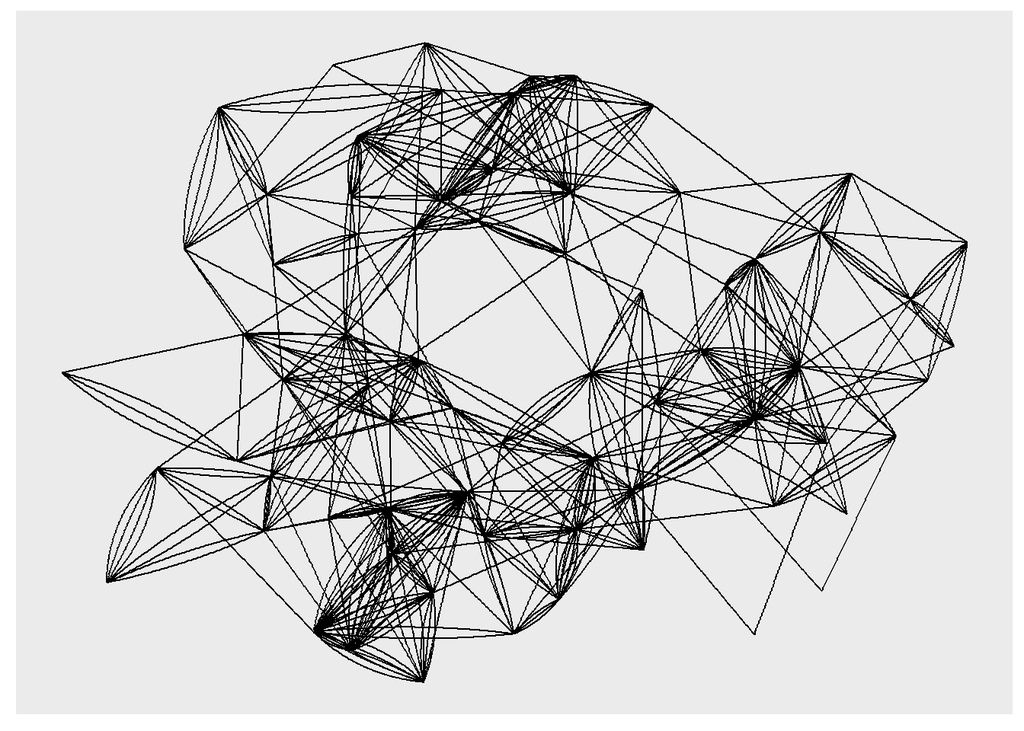

```r
ggraph(hs_graph, layout = "stress") +
  geom_edge_fan()
```

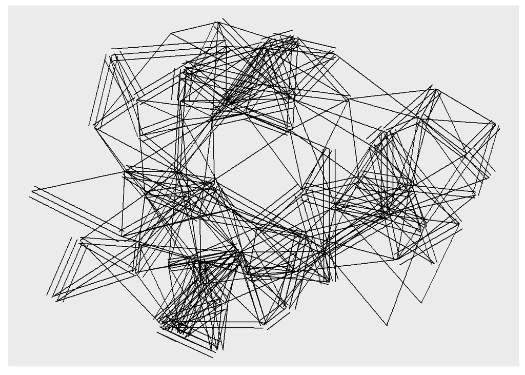

```r
ggraph(hs_graph, layout = "stress") +
  geom_edge_parallel()
```

Estas geomterías solo se deben usar para grafos simples ya que incerementan mucho la información en el gráfica. Viendo Ahora viendo árboles y y dendogramas, un tipo especial es **elbow edge**

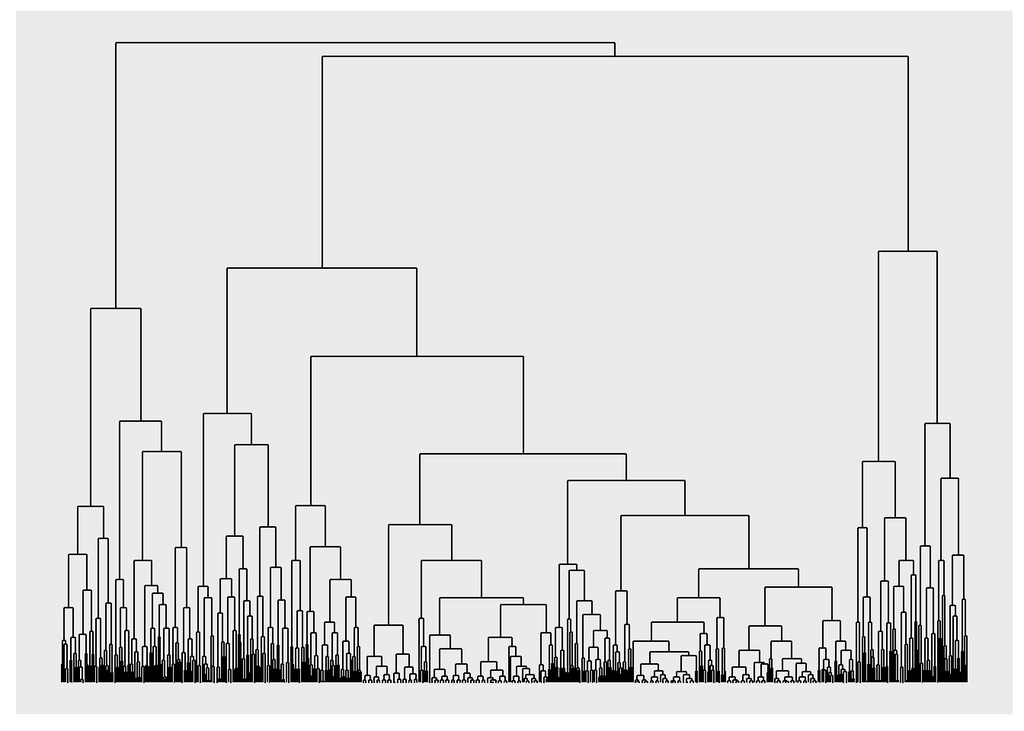

```r
ggraph(luv_graph, layout = "dendrogram", height = height) +
  geom_edge_elbow()
```

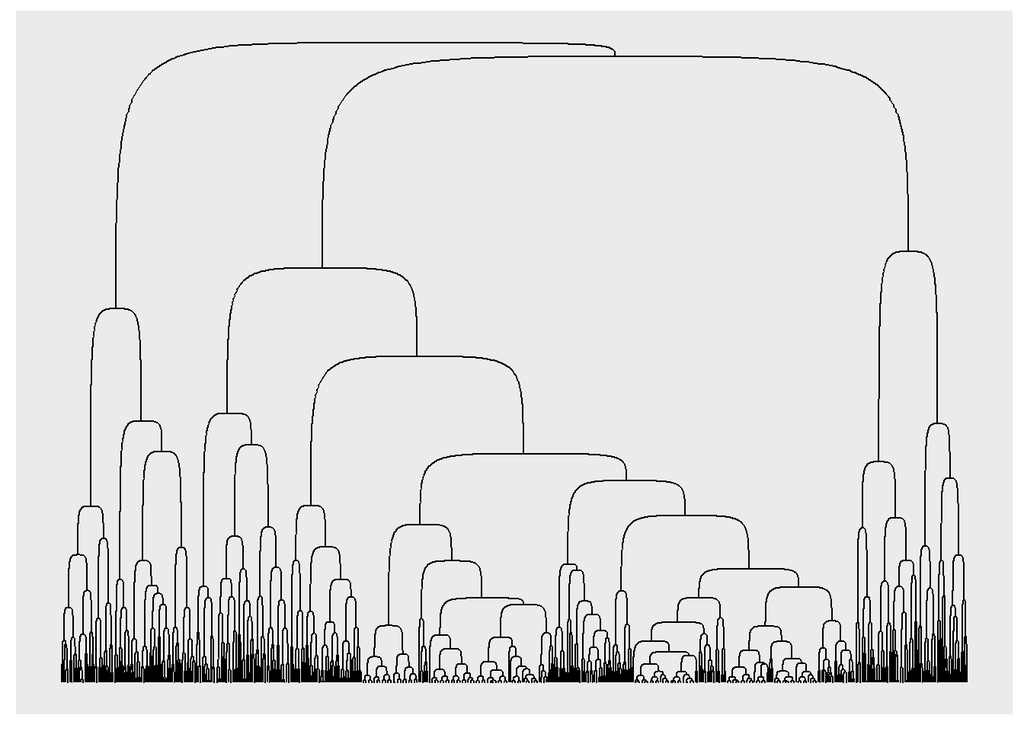

```r
ggraph(luv_graph, layout = "dendrogram", height = height) +
  geom_edge_bend()
```

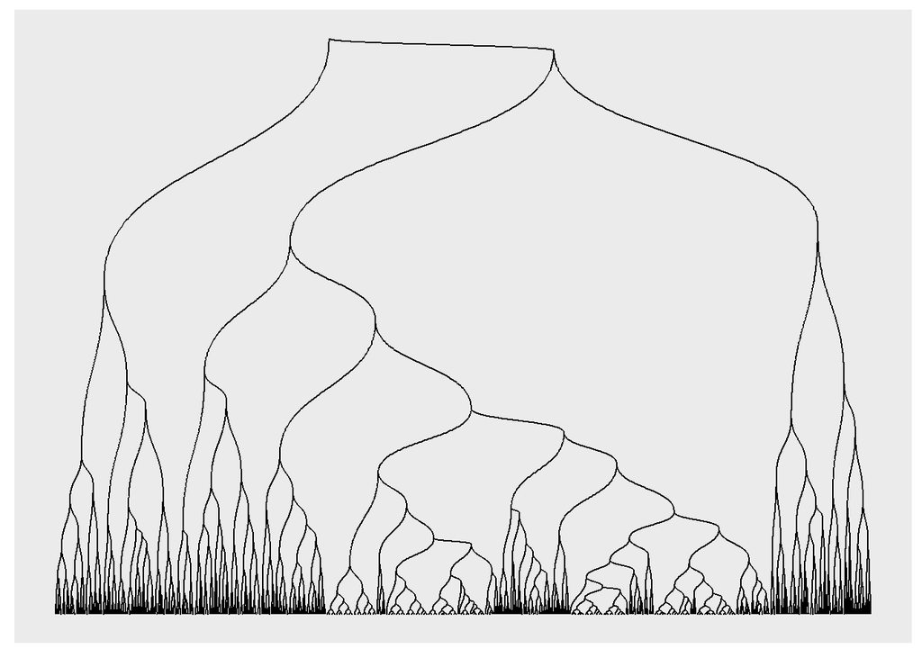

```r
ggraph(luv_graph, layout = "dendrogram", height = height) +
  geom_edge_diagonal()
```

#### Cortando los bordes alrededor de los nodos

Si se usan flechas mostrando la direccionalidad, un problema común es que el nodo va a sobreponerse al borde ya que va hasta el centro del nodo

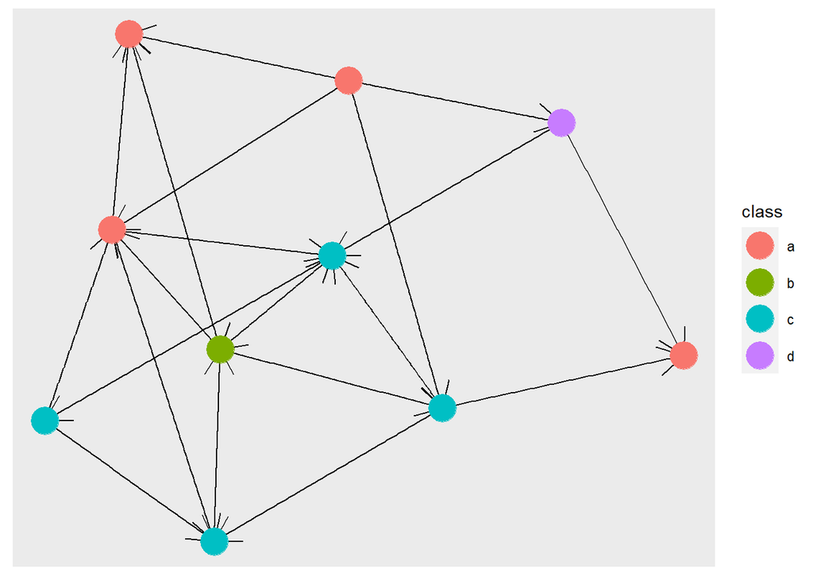

```r
ggraph(graph, layout = "stress") +
  geom_edge_link(arrow = arrow()) +
  geom_node_point(aes(colour = class), size = 8)
```

Queremos que los bordes paren antes de llegar al punto de osecurecer la flecha, usamos `start_cap` y `end_cap`

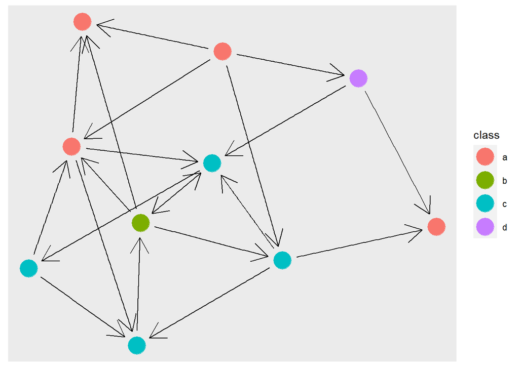

```r
ggraph(graph, layout = "stress") +
  geom_edge_link(
    arrow = arrow(),
    start_cap = circle(5, "mm"),
    end_cap = circle(5, "mm")
  ) +
  geom_node_point(aes(colour = class), size = 8)
```

#### Un borde no siempre es una linea

Los nodos y bordes son conceptos abstractos y se pueden visualizar de diferentes maneras, por ejemplo un gráfico de matriz el cual muestra nodos implicitamente por posición de fila y columna

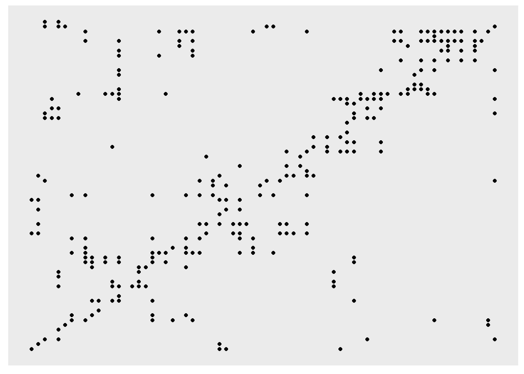

```r
ggraph(hs_graph, layout = "matrix", sort.by = node_rank_traveller()) +
  geom_edge_point()
```

### Faceting

ggraph provee su propia versión de `facet_wrap()` y `facet_grid()`. `facet_nodes()` y `faces_edges()`. Si un borde va entre dos nodos en el mismo panel se va a mostrar en el panel, si se divide en multiples paneles se borrará.

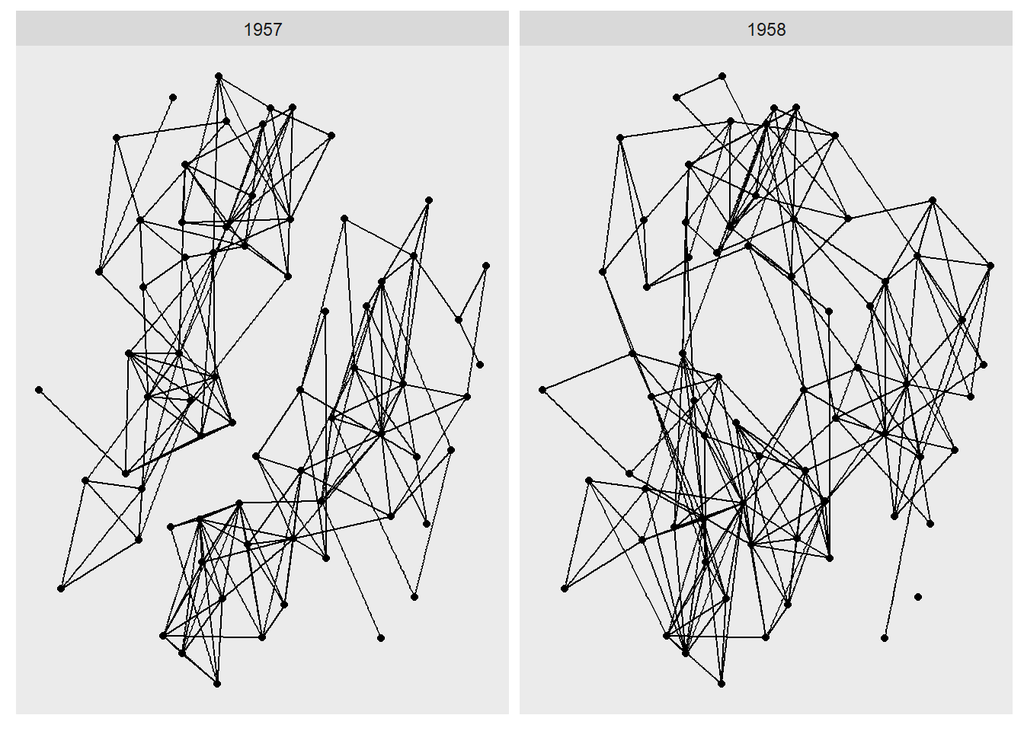

```r
ggraph(hs_graph, layout = "stress") +
  geom_edge_link() +
  geom_node_point() +
  facet_edges(~year)
```

Se ve una evolución en las amistades entre años.

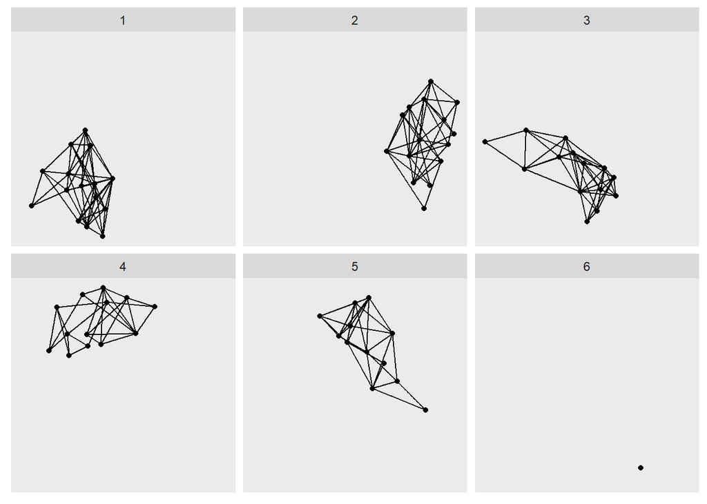

```r
ggraph(hs_graph, layout = "stress") +
  geom_edge_link() +
  geom_node_point() +
  facet_nodes(~ group_spinglass())
```

## Otras fuentes

[Guía tidygraph](https://tidygraph.data-imaginist.com). [Guía ggraph](https://ggraph.data-imaginist.com)